# Final Project - Predicting PDAC with Circulating miRNA

2026-04-23

# Preparing Data

## Import Data

We use the normalized miRNA count matrix from GEO, apply a single log2 transform with a pseudocount of 1, and then merge it with the demographic metadata. Categorical variables are set to factors and the PDAC case and control variable is set to binary for modeling. This ensures that the data is in a suitable format for downstream analysis, including differential expression analysis and predictive modeling.

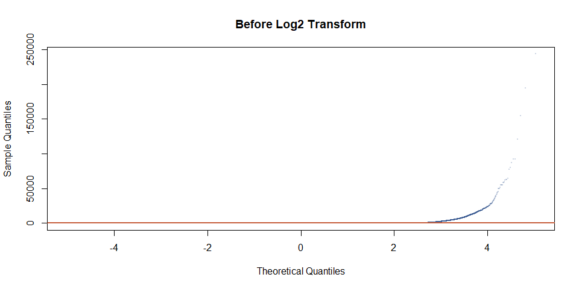

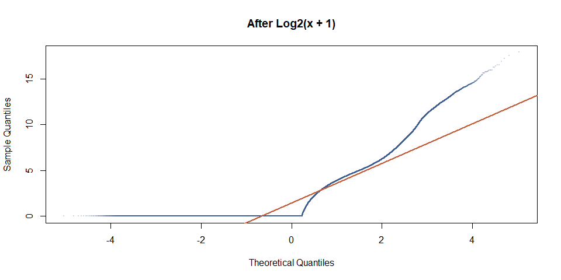

The side-by-side QQ plots below show how the global miRNA value distribution shifts after the import-time log2 transform. The non-linearity of the miRNA counts is evident both before and after log2 transformation. Linearity is non a requirement for the downstream models, but the log2 transformation helps stabilize variance.

The dataset is fully observed with no missing values, so we can proceed without imputation.

## Create Training and Holdout Sets

To split the data while respecting matched-pairs, we performed the split on the matched set IDs, ensuring each pair is not split between sets.

Training and holdout set sizes

| dataset | rows |
| --- | --- |
| Training | 2090 |
| Holdout | 524 |

Training and holdout class balance

| dataset | class | n_samples |
| --- | --- | --- |
| Training | Controls | 1045 |
| Training | PDAC case | 1045 |
| Holdout | Controls | 262 |
| Holdout | PDAC case | 262 |

## Perform Differential Expression Filtering

The limma filtering is based on a blocked linear model with duplicate-correlation adjustment for matched sets and is run once on the full training set. CC is the term of interest and Sex, Race, and Age are adjustment covariates. The top N miRNAs are selected based on the smallest limma p-values, with ties broken by the absolute moderated t-statistic.

## Top 25 miRNAs Selected by Differential Expression

Top 25 blocked limma selected miRNAs on the full training set

| miRNA | mean_control | mean_case | mean_diff | limma_log_fc | limma_avg_expr | limma_t | limma_p_value | limma_adj_p_value | limma_b |
| --- | --- | --- | --- | --- | --- | --- | --- | --- | --- |
| MIMAT0018443 | 0.2589 | 0.3890 | 0.1301 | 0.1312 | 0.3240 | 4.0984 | 0.0000 | 0.0344 | 1.8158 |
| MIMAT0017982 | 0.0357 | 0.0869 | 0.0512 | 0.0512 | 0.0613 | 3.6587 | 0.0003 | 0.1012 | 0.2740 |
| MIMAT0019709 | 2.0728 | 2.2860 | 0.2132 | 0.2139 | 2.1794 | 3.5089 | 0.0005 | 0.1012 | -0.2118 |
| MIMAT0000063 | 5.2460 | 5.0909 | -0.1552 | -0.1540 | 5.1684 | -3.4816 | 0.0005 | 0.1012 | -0.2984 |
| MIMAT0014994 | 0.6166 | 0.7610 | 0.1445 | 0.1448 | 0.6888 | 3.3763 | 0.0007 | 0.1191 | -0.6252 |
| MIMAT0005874 | 0.4489 | 0.5814 | 0.1325 | 0.1333 | 0.5151 | 3.3044 | 0.0010 | 0.1284 | -0.8428 |
| MIMAT0000450 | 2.2605 | 2.4591 | 0.1986 | 0.2028 | 2.3598 | 3.2476 | 0.0012 | 0.1345 | -1.0114 |
| MIMAT0018119 | 1.5270 | 1.7153 | 0.1883 | 0.1904 | 1.6211 | 3.1720 | 0.0015 | 0.1528 | -1.2312 |
| MIMAT0003161 | 1.0814 | 1.2410 | 0.1597 | 0.1616 | 1.1612 | 3.0797 | 0.0021 | 0.1780 | -1.4929 |
| MIMAT0000252 | 0.6134 | 0.7445 | 0.1311 | 0.1332 | 0.6790 | 3.0494 | 0.0023 | 0.1780 | -1.5769 |
| MIMAT0003310 | 1.4193 | 1.5873 | 0.1680 | 0.1701 | 1.5033 | 2.9316 | 0.0034 | 0.1780 | -1.8965 |
| MIMAT0000280 | 8.6435 | 8.4313 | -0.2122 | -0.2116 | 8.5374 | -2.8912 | 0.0039 | 0.1780 | -2.0032 |
| MIMAT0005800 | 1.0859 | 1.2294 | 0.1435 | 0.1447 | 1.1577 | 2.8818 | 0.0040 | 0.1780 | -2.0278 |
| MIMAT0003313 | 0.4205 | 0.5251 | 0.1046 | 0.1044 | 0.4728 | 2.8809 | 0.0040 | 0.1780 | -2.0302 |
| MIMAT0005914 | 2.9360 | 3.1160 | 0.1800 | 0.1790 | 3.0260 | 2.8738 | 0.0041 | 0.1780 | -2.0485 |
| MIMAT0000440 | 4.6367 | 4.4216 | -0.2151 | -0.2134 | 4.5291 | -2.8660 | 0.0042 | 0.1780 | -2.0689 |
| MIMAT0006764 | 0.0658 | 0.1117 | 0.0459 | 0.0460 | 0.0887 | 2.8641 | 0.0042 | 0.1780 | -2.0739 |
| MIMAT0003268 | 0.1763 | 0.2510 | 0.0747 | 0.0750 | 0.2137 | 2.8478 | 0.0044 | 0.1780 | -2.1162 |
| MIMAT0015058 | 0.6290 | 0.7520 | 0.1230 | 0.1251 | 0.6905 | 2.8427 | 0.0045 | 0.1780 | -2.1292 |
| MIMAT0026486 | 1.1207 | 1.2591 | 0.1385 | 0.1381 | 1.1899 | 2.8405 | 0.0045 | 0.1780 | -2.1350 |
| MIMAT0002823 | 0.0071 | 0.0287 | 0.0216 | 0.0216 | 0.0179 | 2.8226 | 0.0048 | 0.1780 | -2.1810 |
| MIMAT0004679 | 0.4755 | 0.5846 | 0.1091 | 0.1103 | 0.5301 | 2.8153 | 0.0049 | 0.1780 | -2.1996 |
| MIMAT0000646 | 2.2769 | 2.4225 | 0.1456 | 0.1458 | 2.3497 | 2.7187 | 0.0066 | 0.2287 | -2.4421 |
| MIMAT0000271 | 0.2736 | 0.2001 | -0.0735 | -0.0729 | 0.2369 | -2.6443 | 0.0082 | 0.2735 | -2.6232 |
| MIMAT0005953 | 1.0008 | 1.1395 | 0.1387 | 0.1415 | 1.0701 | 2.6102 | 0.0091 | 0.2902 | -2.7045 |

The top-ranked miRNAs table has 25 rows and 10 columns. The selected miRNAs vector has 25 miRNAs. The blocked-limma ranking shown above is reported for reference only; all models use the full log2-transformed miRNA set because include_limma_filter is FALSE.

# Cross-Validation Loop

We perform a 10-fold cross-validation on the training set of paired samples, ensuring matched-samples are kept together in the same fold.

Within each fold: 1. All models receive the full log2-transformed miRNA set without limma prefiltering. 2. We then fit each model using its assigned miRNA input pool together with Sex, Race, and Age in the design. 3. The LDA and forward-step models additionally standardize only the selected miRNA log-count columns using training-fold means and standard deviations before fitting, and apply the same transformation to the corresponding validation data. 4. The lasso and elastic-net models use `alpha` and `lambda` values chosen once on the full training split, then keep those values fixed throughout the outer cross-validation loop and the final holdout fit. 5. The random forest model additionally evaluates 20, 30, and 40 as candidate `mtry` values and keeps the fit with the lowest out-of-bag classification error.

Cross-validation AUC and accuracy by model

| model | n_predictions | cv_auc | cv_accuracy |
| --- | --- | --- | --- |
| random_forest | 2090 | 0.534 | 0.524 |
| lda | 2090 | 0.522 | 0.523 |
| lasso | 2090 | 0.512 | 0.505 |
| decision_tree | 2090 | 0.508 | 0.508 |
| enet | 2090 | 0.508 | 0.503 |
| forward_step | 2090 | 0.489 | 0.494 |

### ROC-AUC Plots for CV Folds

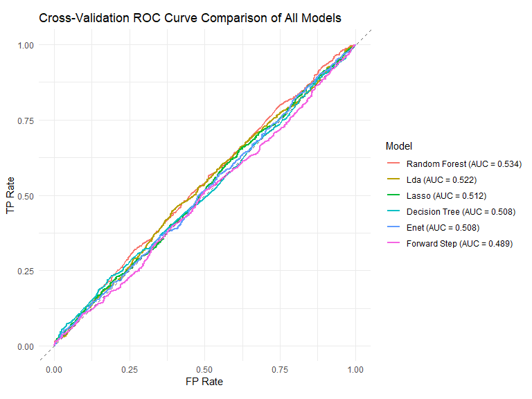

This plot compares the ROC curves for all models across the pooled cross-validation predictions.

### Stable Features in CV Folds

Summarize feature selection stability across folds for each model

#### Forward Step

Top stable features for Forward Step

| miRNA | n_folds_selected |
| --- | --- |
| MIMAT0000063 | 9 |
| MIMAT0018443 | 9 |
| MIMAT0000271 | 8 |
| MIMAT0001545 | 8 |
| MIMAT0003313 | 8 |
| MIMAT0014994 | 8 |
| MIMAT0000072 | 7 |
| MIMAT0002855 | 7 |
| MIMAT0006764 | 7 |
| MIMAT0000087 | 6 |
| MIMAT0017982 | 6 |
| MIMAT0000416 | 5 |
| MIMAT0000450 | 5 |
| MIMAT0002823 | 5 |
| MIMAT0003161 | 5 |
| MIMAT0003268 | 5 |
| MIMAT0004679 | 5 |
| MIMAT0005454 | 5 |
| MIMAT0005914 | 5 |
| MIMAT0015058 | 5 |

Selected miRNA counts by fold for Forward Step

| fold | n_selected_miRNA |
| --- | --- |
| 1 | 25 |
| 2 | 25 |
| 3 | 25 |
| 4 | 25 |
| 5 | 25 |
| 6 | 25 |
| 7 | 25 |
| 8 | 25 |
| 9 | 25 |
| 10 | 25 |

Tuning summary for Forward Step

| model | n_selected_miRNA | n_terms | scaled_predictors |
| --- | --- | --- | --- |
| forward_step | 25 | 30 | TRUE |
| forward_step | 25 | 30 | TRUE |
| forward_step | 25 | 30 | TRUE |
| forward_step | 25 | 30 | TRUE |
| forward_step | 25 | 30 | TRUE |
| forward_step | 25 | 30 | TRUE |
| forward_step | 25 | 30 | TRUE |
| forward_step | 25 | 30 | TRUE |
| forward_step | 25 | 30 | TRUE |
| forward_step | 25 | 30 | TRUE |

#### Lasso

Top stable features for Lasso

| miRNA | n_folds_selected |
| --- | --- |
| MIMAT0000063 | 10 |
| MIMAT0017982 | 10 |
| MIMAT0018443 | 10 |
| MIMAT0005874 | 9 |
| MIMAT0014994 | 9 |
| MIMAT0019709 | 9 |
| MIMAT0000271 | 8 |
| MIMAT0003268 | 8 |
| MIMAT0006764 | 8 |
| MIMAT0002823 | 7 |
| MIMAT0003313 | 4 |
| MIMAT0005800 | 4 |
| MIMAT0005898 | 4 |
| MIMAT0015058 | 4 |
| MIMAT0018119 | 4 |
| MIMAT0019062 | 4 |
| MIMAT0022839 | 4 |
| MIMAT0026734 | 4 |
| MIMAT0001545 | 3 |
| MIMAT0005454 | 3 |

Selected miRNA counts by fold for Lasso

| fold | n_selected_miRNA |
| --- | --- |
| 1 | 14 |
| 2 | 16 |
| 3 | 16 |
| 4 | 17 |
| 5 | 17 |
| 6 | 20 |
| 7 | 12 |
| 8 | 12 |
| 9 | 18 |
| 10 | 13 |

Tuning summary for Lasso

| model | n_selected_miRNA | alpha | lambda | cv_score | alpha_grid | tuning_source |
| --- | --- | --- | --- | --- | --- | --- |
| lasso | 14 | 0.35 | 0.062 | 1.39 | 0.1,0.15,0.2,0.25,0.3,0.35,0.4,0.45,0.5,0.55,0.6,0.65,0.7,0.75,0.8,0.85,0.9,0.95,1 | fixed_from_full_training_set |
| lasso | 16 | 0.35 | 0.062 | 1.39 | 0.1,0.15,0.2,0.25,0.3,0.35,0.4,0.45,0.5,0.55,0.6,0.65,0.7,0.75,0.8,0.85,0.9,0.95,1 | fixed_from_full_training_set |
| lasso | 16 | 0.35 | 0.062 | 1.39 | 0.1,0.15,0.2,0.25,0.3,0.35,0.4,0.45,0.5,0.55,0.6,0.65,0.7,0.75,0.8,0.85,0.9,0.95,1 | fixed_from_full_training_set |
| lasso | 17 | 0.35 | 0.062 | 1.39 | 0.1,0.15,0.2,0.25,0.3,0.35,0.4,0.45,0.5,0.55,0.6,0.65,0.7,0.75,0.8,0.85,0.9,0.95,1 | fixed_from_full_training_set |
| lasso | 17 | 0.35 | 0.062 | 1.39 | 0.1,0.15,0.2,0.25,0.3,0.35,0.4,0.45,0.5,0.55,0.6,0.65,0.7,0.75,0.8,0.85,0.9,0.95,1 | fixed_from_full_training_set |
| lasso | 20 | 0.35 | 0.062 | 1.39 | 0.1,0.15,0.2,0.25,0.3,0.35,0.4,0.45,0.5,0.55,0.6,0.65,0.7,0.75,0.8,0.85,0.9,0.95,1 | fixed_from_full_training_set |
| lasso | 12 | 0.35 | 0.062 | 1.39 | 0.1,0.15,0.2,0.25,0.3,0.35,0.4,0.45,0.5,0.55,0.6,0.65,0.7,0.75,0.8,0.85,0.9,0.95,1 | fixed_from_full_training_set |
| lasso | 12 | 0.35 | 0.062 | 1.39 | 0.1,0.15,0.2,0.25,0.3,0.35,0.4,0.45,0.5,0.55,0.6,0.65,0.7,0.75,0.8,0.85,0.9,0.95,1 | fixed_from_full_training_set |
| lasso | 18 | 0.35 | 0.062 | 1.39 | 0.1,0.15,0.2,0.25,0.3,0.35,0.4,0.45,0.5,0.55,0.6,0.65,0.7,0.75,0.8,0.85,0.9,0.95,1 | fixed_from_full_training_set |
| lasso | 13 | 0.35 | 0.062 | 1.39 | 0.1,0.15,0.2,0.25,0.3,0.35,0.4,0.45,0.5,0.55,0.6,0.65,0.7,0.75,0.8,0.85,0.9,0.95,1 | fixed_from_full_training_set |

#### Enet

Top stable features for Enet

| miRNA | n_folds_selected |
| --- | --- |
| MIMAT0017982 | 10 |
| MIMAT0018443 | 10 |
| MIMAT0000063 | 9 |
| MIMAT0019709 | 9 |
| MIMAT0014994 | 8 |
| MIMAT0005874 | 6 |
| MIMAT0002823 | 5 |
| MIMAT0006764 | 5 |
| MIMAT0000271 | 3 |
| MIMAT0003268 | 3 |
| MIMAT0018119 | 3 |
| MIMAT0005898 | 2 |
| MIMAT0022839 | 2 |
| MIMAT0000252 | 1 |
| MIMAT0001545 | 1 |
| MIMAT0002854 | 1 |
| MIMAT0003165 | 1 |
| MIMAT0003313 | 1 |
| MIMAT0004679 | 1 |
| MIMAT0005454 | 1 |

Selected miRNA counts by fold for Enet

| fold | n_selected_miRNA |
| --- | --- |
| 1 | 8 |
| 2 | 9 |
| 3 | 7 |
| 4 | 9 |
| 5 | 7 |
| 6 | 10 |
| 7 | 10 |
| 8 | 9 |
| 9 | 11 |
| 10 | 8 |

Tuning summary for Enet

| model | n_selected_miRNA | alpha | lambda | cv_score | alpha_grid | tuning_source |
| --- | --- | --- | --- | --- | --- | --- |
| enet | 8 | 0.95 | 0.025 | 1.39 | 0.1,0.15,0.2,0.25,0.3,0.35,0.4,0.45,0.5,0.55,0.6,0.65,0.7,0.75,0.8,0.85,0.9,0.95,1 | fixed_from_full_training_set |
| enet | 9 | 0.95 | 0.025 | 1.39 | 0.1,0.15,0.2,0.25,0.3,0.35,0.4,0.45,0.5,0.55,0.6,0.65,0.7,0.75,0.8,0.85,0.9,0.95,1 | fixed_from_full_training_set |
| enet | 7 | 0.95 | 0.025 | 1.39 | 0.1,0.15,0.2,0.25,0.3,0.35,0.4,0.45,0.5,0.55,0.6,0.65,0.7,0.75,0.8,0.85,0.9,0.95,1 | fixed_from_full_training_set |
| enet | 9 | 0.95 | 0.025 | 1.39 | 0.1,0.15,0.2,0.25,0.3,0.35,0.4,0.45,0.5,0.55,0.6,0.65,0.7,0.75,0.8,0.85,0.9,0.95,1 | fixed_from_full_training_set |
| enet | 7 | 0.95 | 0.025 | 1.39 | 0.1,0.15,0.2,0.25,0.3,0.35,0.4,0.45,0.5,0.55,0.6,0.65,0.7,0.75,0.8,0.85,0.9,0.95,1 | fixed_from_full_training_set |
| enet | 10 | 0.95 | 0.025 | 1.39 | 0.1,0.15,0.2,0.25,0.3,0.35,0.4,0.45,0.5,0.55,0.6,0.65,0.7,0.75,0.8,0.85,0.9,0.95,1 | fixed_from_full_training_set |
| enet | 10 | 0.95 | 0.025 | 1.39 | 0.1,0.15,0.2,0.25,0.3,0.35,0.4,0.45,0.5,0.55,0.6,0.65,0.7,0.75,0.8,0.85,0.9,0.95,1 | fixed_from_full_training_set |
| enet | 9 | 0.95 | 0.025 | 1.39 | 0.1,0.15,0.2,0.25,0.3,0.35,0.4,0.45,0.5,0.55,0.6,0.65,0.7,0.75,0.8,0.85,0.9,0.95,1 | fixed_from_full_training_set |
| enet | 11 | 0.95 | 0.025 | 1.39 | 0.1,0.15,0.2,0.25,0.3,0.35,0.4,0.45,0.5,0.55,0.6,0.65,0.7,0.75,0.8,0.85,0.9,0.95,1 | fixed_from_full_training_set |
| enet | 8 | 0.95 | 0.025 | 1.39 | 0.1,0.15,0.2,0.25,0.3,0.35,0.4,0.45,0.5,0.55,0.6,0.65,0.7,0.75,0.8,0.85,0.9,0.95,1 | fixed_from_full_training_set |

#### Lda

Top stable features for Lda

| miRNA | n_folds_selected |
| --- | --- |
| MIMAT0000062 | 10 |
| MIMAT0000063 | 10 |
| MIMAT0000064 | 10 |
| MIMAT0000065 | 10 |
| MIMAT0000066 | 10 |
| MIMAT0000067 | 10 |
| MIMAT0000098 | 10 |
| MIMAT0000099 | 10 |
| MIMAT0000101 | 10 |
| MIMAT0000102 | 10 |
| MIMAT0000103 | 10 |
| MIMAT0000104 | 10 |
| MIMAT0000253 | 10 |
| MIMAT0000254 | 10 |
| MIMAT0000414 | 10 |
| MIMAT0000415 | 10 |
| MIMAT0000416 | 10 |
| MIMAT0000680 | 10 |
| MIMAT0005823 | 10 |
| MIMAT0031892 | 10 |

Selected miRNA counts by fold for Lda

| fold | n_selected_miRNA |
| --- | --- |
| 1 | 20 |
| 2 | 20 |
| 3 | 20 |
| 4 | 20 |
| 5 | 20 |
| 6 | 20 |
| 7 | 20 |
| 8 | 20 |
| 9 | 20 |
| 10 | 20 |

Tuning summary for Lda

| model | n_selected_miRNA | n_features | prior | scaled_predictors |
| --- | --- | --- | --- | --- |
| lda | 20 | 20 | 0.5,0.5 | TRUE |
| lda | 20 | 20 | 0.5,0.5 | TRUE |
| lda | 20 | 20 | 0.5,0.5 | TRUE |
| lda | 20 | 20 | 0.5,0.5 | TRUE |
| lda | 20 | 20 | 0.5,0.5 | TRUE |
| lda | 20 | 20 | 0.5,0.5 | TRUE |
| lda | 20 | 20 | 0.5,0.5 | TRUE |
| lda | 20 | 20 | 0.5,0.5 | TRUE |
| lda | 20 | 20 | 0.5,0.5 | TRUE |
| lda | 20 | 20 | 0.5,0.5 | TRUE |

#### Random Forest

Top stable features for Random Forest

| miRNA | n_folds_selected |
| --- | --- |
| MIMAT0000063 | 5 |
| MIMAT0000730 | 4 |
| MIMAT0004775 | 4 |
| MIMAT0004985 | 4 |
| MIMAT0017992 | 4 |
| MIMAT0000103 | 3 |
| MIMAT0000421 | 3 |
| MIMAT0000450 | 3 |
| MIMAT0001545 | 3 |
| MIMAT0002830 | 3 |
| MIMAT0004945 | 3 |
| MIMAT0005878 | 3 |
| MIMAT0005916 | 3 |
| MIMAT0000231 | 2 |
| MIMAT0000243 | 2 |
| MIMAT0000253 | 2 |
| MIMAT0000267 | 2 |
| MIMAT0000427 | 2 |
| MIMAT0000430 | 2 |
| MIMAT0000440 | 2 |

Selected miRNA counts by fold for Random Forest

| fold | n_selected_miRNA |
| --- | --- |
| 1 | 25 |
| 2 | 25 |
| 3 | 25 |
| 4 | 25 |
| 5 | 25 |
| 6 | 25 |
| 7 | 25 |
| 8 | 25 |
| 9 | 25 |
| 10 | 25 |

Tuning summary for Random Forest

| model | n_selected_miRNA | ntree | ntree_search_max | mtry | optimal_ntree | oob_error | oob_error_search_min | oob_error_smoothed_selected | ntree_selection_burn_in | ntree_selection_smoothing_window | importance_metric | top_m_features |
| --- | --- | --- | --- | --- | --- | --- | --- | --- | --- | --- | --- | --- |
| random_forest | 25 | 118 | 200 | 40 | 118 | 0.504 | 0.487 | 0.493 | 25 | 10 | MeanDecreaseAccuracy | 25 |
| random_forest | 25 | 180 | 200 | 20 | 180 | 0.499 | 0.494 | 0.497 | 25 | 10 | MeanDecreaseAccuracy | 25 |
| random_forest | 25 | 77 | 200 | 30 | 77 | 0.529 | 0.471 | 0.478 | 25 | 10 | MeanDecreaseAccuracy | 25 |
| random_forest | 25 | 110 | 200 | 20 | 110 | 0.505 | 0.494 | 0.501 | 25 | 10 | MeanDecreaseAccuracy | 25 |
| random_forest | 25 | 86 | 200 | 20 | 86 | 0.486 | 0.481 | 0.486 | 25 | 10 | MeanDecreaseAccuracy | 25 |
| random_forest | 25 | 164 | 200 | 30 | 164 | 0.518 | 0.486 | 0.490 | 25 | 10 | MeanDecreaseAccuracy | 25 |
| random_forest | 25 | 69 | 200 | 40 | 69 | 0.496 | 0.478 | 0.485 | 25 | 10 | MeanDecreaseAccuracy | 25 |
| random_forest | 25 | 65 | 200 | 40 | 65 | 0.497 | 0.476 | 0.483 | 25 | 10 | MeanDecreaseAccuracy | 25 |
| random_forest | 25 | 51 | 200 | 30 | 51 | 0.489 | 0.476 | 0.483 | 25 | 10 | MeanDecreaseAccuracy | 25 |
| random_forest | 25 | 26 | 200 | 20 | 26 | 0.496 | 0.482 | 0.493 | 25 | 10 | MeanDecreaseAccuracy | 25 |

#### Decision Tree

Top stable features for Decision Tree

| miRNA | n_folds_selected |
| --- | --- |
| MIMAT0001545 | 10 |
| MIMAT0000687 | 7 |
| MIMAT0000271 | 6 |
| MIMAT0003161 | 6 |
| MIMAT0003259 | 6 |
| MIMAT0000261 | 5 |
| MIMAT0005896 | 5 |
| MIMAT0019058 | 5 |
| MIMAT0000065 | 4 |
| MIMAT0000076 | 4 |
| MIMAT0005876 | 4 |
| MIMAT0018940 | 4 |
| MIMAT0019748 | 4 |
| MIMAT0000063 | 3 |
| MIMAT0000066 | 3 |
| MIMAT0000075 | 3 |
| MIMAT0000232 | 3 |
| MIMAT0000421 | 3 |
| MIMAT0000446 | 3 |
| MIMAT0000450 | 3 |

Selected miRNA counts by fold for Decision Tree

| fold | n_selected_miRNA |
| --- | --- |
| 1 | 61 |
| 2 | 50 |
| 3 | 57 |
| 4 | 58 |
| 5 | 48 |
| 6 | 63 |
| 7 | 40 |
| 8 | 49 |
| 9 | 38 |
| 10 | 50 |

Tuning summary for Decision Tree

| model | n_selected_miRNA | cp | maxdepth | n_terms | n_nonzero_importance |
| --- | --- | --- | --- | --- | --- |
| decision_tree | 61 | 0.001 | 14 | 63 | 293 |
| decision_tree | 50 | 0.001 | 14 | 50 | 246 |
| decision_tree | 57 | 0.001 | 14 | 58 | 269 |
| decision_tree | 58 | 0.001 | 14 | 58 | 268 |
| decision_tree | 48 | 0.001 | 14 | 48 | 250 |
| decision_tree | 63 | 0.001 | 14 | 63 | 293 |
| decision_tree | 40 | 0.001 | 14 | 40 | 199 |
| decision_tree | 49 | 0.001 | 14 | 49 | 240 |
| decision_tree | 38 | 0.001 | 14 | 38 | 199 |
| decision_tree | 50 | 0.001 | 14 | 51 | 247 |

Number of miRNAs supplied to each model by fold

| model | fold | n_preselected_miRNA |
| --- | --- | --- |
| Forward Step | 1 | 796 |
| Forward Step | 2 | 796 |
| Forward Step | 3 | 796 |
| Forward Step | 4 | 796 |
| Forward Step | 5 | 796 |
| Forward Step | 6 | 796 |
| Forward Step | 7 | 796 |
| Forward Step | 8 | 796 |
| Forward Step | 9 | 796 |
| Forward Step | 10 | 796 |
| Lasso | 1 | 796 |
| Lasso | 2 | 796 |
| Lasso | 3 | 796 |
| Lasso | 4 | 796 |
| Lasso | 5 | 796 |
| Lasso | 6 | 796 |
| Lasso | 7 | 796 |
| Lasso | 8 | 796 |
| Lasso | 9 | 796 |
| Lasso | 10 | 796 |
| Enet | 1 | 796 |
| Enet | 2 | 796 |
| Enet | 3 | 796 |
| Enet | 4 | 796 |
| Enet | 5 | 796 |
| Enet | 6 | 796 |
| Enet | 7 | 796 |
| Enet | 8 | 796 |
| Enet | 9 | 796 |
| Enet | 10 | 796 |
| Lda | 1 | 796 |
| Lda | 2 | 796 |
| Lda | 3 | 796 |
| Lda | 4 | 796 |
| Lda | 5 | 796 |
| Lda | 6 | 796 |
| Lda | 7 | 796 |
| Lda | 8 | 796 |
| Lda | 9 | 796 |
| Lda | 10 | 796 |
| Random Forest | 1 | 796 |
| Random Forest | 2 | 796 |
| Random Forest | 3 | 796 |
| Random Forest | 4 | 796 |
| Random Forest | 5 | 796 |
| Random Forest | 6 | 796 |
| Random Forest | 7 | 796 |
| Random Forest | 8 | 796 |
| Random Forest | 9 | 796 |
| Random Forest | 10 | 796 |
| Decision Tree | 1 | 796 |
| Decision Tree | 2 | 796 |
| Decision Tree | 3 | 796 |
| Decision Tree | 4 | 796 |
| Decision Tree | 5 | 796 |
| Decision Tree | 6 | 796 |
| Decision Tree | 7 | 796 |
| Decision Tree | 8 | 796 |
| Decision Tree | 9 | 796 |
| Decision Tree | 10 | 796 |

## Holdout Evaluation

Evaluate the final fold, using the calibrated models from the CV step, on the holdout set. We report AUC and accuracy for each model on the holdout set, as well as the number of features selected in each final model and the size of each model’s input miRNA pool.

Holdout AUC and accuracy by model

| model | test_accuracy | test_auc |
| --- | --- | --- |
| lda | 0.532 | 0.534 |
| lasso | 0.466 | 0.534 |
| enet | 0.485 | 0.529 |
| decision_tree | 0.477 | 0.517 |
| forward_step | 0.490 | 0.508 |
| random_forest | 0.517 | 0.505 |

Final model diagnostics

| model | n_prob | n_selected_miRNA |
| --- | --- | --- |
| forward_step | 524 | 25 |
| lasso | 524 | 12 |
| enet | 524 | 8 |
| lda | 524 | 20 |
| random_forest | 524 | 25 |
| decision_tree | 524 | 50 |

Selected miRNA counts in final holdout models

| model | n_selected_miRNA |
| --- | --- |
| forward_step | 25 |
| lasso | 12 |
| enet | 8 |
| lda | 20 |
| random_forest | 25 |
| decision_tree | 50 |

Final variables used by each holdout model

| model | n_final_variables | demographic_variables | miRNA_variables | final_variables |
| --- | --- | --- | --- | --- |
| Forward Step | 30 | SexMale, RaceBlack, RaceWhite, RaceOthers, and Age | MIMAT0018443, MIMAT0000063, MIMAT0014994, MIMAT0017982, MIMAT0000416, MIMAT0003161, MIMAT0000271, MIMAT0001545, MIMAT0000450, MIMAT0000072, MIMAT0003313, MIMAT0005914, MIMAT0002825, MIMAT0002855, MIMA… | SexMale, RaceBlack, RaceWhite, RaceOthers, Age, MIMAT0018443, MIMAT0000063, MIMAT0014994, MIMAT0017982, MIMAT0000416, MIMAT0003161, MIMAT0000271, MIMAT0001545, MIMAT0000450, MIMAT0000072, MIMAT0003313… |
| Lasso | 17 | SexMale, RaceBlack, RaceWhite, RaceOthers, and Age | MIMAT0000063, MIMAT0000271, MIMAT0014994, MIMAT0022839, MIMAT0006764, MIMAT0017982, MIMAT0018119, MIMAT0018443, MIMAT0019709, MIMAT0002823, MIMAT0005874, and MIMAT0003268 | SexMale, RaceBlack, RaceWhite, RaceOthers, Age, MIMAT0000063, MIMAT0000271, MIMAT0014994, MIMAT0022839, MIMAT0006764, MIMAT0017982, MIMAT0018119, MIMAT0018443, MIMAT0019709, MIMAT0002823, MIMAT0005874… |
| Enet | 13 | SexMale, RaceBlack, RaceWhite, RaceOthers, and Age | MIMAT0000063, MIMAT0014994, MIMAT0006764, MIMAT0017982, MIMAT0018443, MIMAT0019709, MIMAT0002823, and MIMAT0005874 | SexMale, RaceBlack, RaceWhite, RaceOthers, Age, MIMAT0000063, MIMAT0014994, MIMAT0006764, MIMAT0017982, MIMAT0018443, MIMAT0019709, MIMAT0002823, and MIMAT0005874 |
| Lda | 25 | SexMale, RaceBlack, RaceWhite, RaceOthers, and Age | MIMAT0000062, MIMAT0000063, MIMAT0000064, MIMAT0000065, MIMAT0000066, MIMAT0000067, MIMAT0000414, MIMAT0000415, MIMAT0000416, MIMAT0031892, MIMAT0000098, MIMAT0000099, MIMAT0000101, MIMAT0000102, MIMA… | SexMale, RaceBlack, RaceWhite, RaceOthers, Age, MIMAT0000062, MIMAT0000063, MIMAT0000064, MIMAT0000065, MIMAT0000066, MIMAT0000067, MIMAT0000414, MIMAT0000415, MIMAT0000416, MIMAT0031892, MIMAT0000098… |
| Random Forest | 30 | SexMale, RaceBlack, RaceWhite, RaceOthers, and Age | MIMAT0001631, MIMAT0000427, MIMAT0015020, MIMAT0000273, MIMAT0001545, MIMAT0003220, MIMAT0019053, MIMAT0000692, MIMAT0018925, MIMAT0000440, MIMAT0000065, MIMAT0004985, MIMAT0002844, MIMAT0002846, MIMA… | SexMale, RaceBlack, RaceWhite, RaceOthers, Age, MIMAT0001631, MIMAT0000427, MIMAT0015020, MIMAT0000273, MIMAT0001545, MIMAT0003220, MIMAT0019053, MIMAT0000692, MIMAT0018925, MIMAT0000440, MIMAT0000065… |
| Decision Tree | 50 | None | MIMAT0000687, MIMAT0000261, MIMAT0015050, MIMAT0003161, MIMAT0001545, MIMAT0000066, MIMAT0002883, MIMAT0003282, MIMAT0000751, MIMAT0002854, MIMAT0003258, MIMAT0000271, MIMAT0000063, MIMAT0018940, MIMA… | MIMAT0000687, MIMAT0000261, MIMAT0015050, MIMAT0003161, MIMAT0001545, MIMAT0000066, MIMAT0002883, MIMAT0003282, MIMAT0000751, MIMAT0002854, MIMAT0003258, MIMAT0000271, MIMAT0000063, MIMAT0018940, MIMA… |

Final variable inclusion matrix across holdout models

| variable | variable_type | Forward Step | Lasso | Enet | Lda | Random Forest | Decision Tree | n_models_selected |
| --- | --- | --- | --- | --- | --- | --- | --- | --- |
| Age | Demographic | Yes | Yes | Yes | Yes | Yes |  | 5 |
| RaceBlack | Demographic | Yes | Yes | Yes | Yes | Yes |  | 5 |
| RaceOthers | Demographic | Yes | Yes | Yes | Yes | Yes |  | 5 |
| RaceWhite | Demographic | Yes | Yes | Yes | Yes | Yes |  | 5 |
| SexMale | Demographic | Yes | Yes | Yes | Yes | Yes |  | 5 |
| MIMAT0000063 | miRNA | Yes | Yes | Yes | Yes |  | Yes | 5 |
| MIMAT0000065 | miRNA |  |  |  | Yes | Yes | Yes | 3 |
| MIMAT0000271 | miRNA | Yes | Yes |  |  |  | Yes | 3 |
| MIMAT0001545 | miRNA | Yes |  |  |  | Yes | Yes | 3 |
| MIMAT0006764 | miRNA | Yes | Yes | Yes |  |  |  | 3 |
| MIMAT0014994 | miRNA | Yes | Yes | Yes |  |  |  | 3 |
| MIMAT0017982 | miRNA | Yes | Yes | Yes |  |  |  | 3 |
| MIMAT0018443 | miRNA | Yes | Yes | Yes |  |  |  | 3 |
| MIMAT0019709 | miRNA | Yes | Yes | Yes |  |  |  | 3 |
| MIMAT0000066 | miRNA |  |  |  | Yes |  | Yes | 2 |
| MIMAT0000101 | miRNA | Yes |  |  | Yes |  |  | 2 |
| MIMAT0000103 | miRNA |  |  |  | Yes |  | Yes | 2 |
| MIMAT0000272 | miRNA |  |  |  |  | Yes | Yes | 2 |
| MIMAT0000281 | miRNA |  |  |  |  | Yes | Yes | 2 |
| MIMAT0000415 | miRNA | Yes |  |  | Yes |  |  | 2 |
| MIMAT0000416 | miRNA | Yes |  |  | Yes |  |  | 2 |
| MIMAT0001631 | miRNA |  |  |  |  | Yes | Yes | 2 |
| MIMAT0002823 | miRNA |  | Yes | Yes |  |  |  | 2 |
| MIMAT0003161 | miRNA | Yes |  |  |  |  | Yes | 2 |
| MIMAT0003268 | miRNA | Yes | Yes |  |  |  |  | 2 |
| MIMAT0003332 | miRNA |  |  |  |  | Yes | Yes | 2 |
| MIMAT0005874 | miRNA |  | Yes | Yes |  |  |  | 2 |
| MIMAT0005914 | miRNA | Yes |  |  |  |  | Yes | 2 |
| MIMAT0018925 | miRNA |  |  |  |  | Yes | Yes | 2 |
| MIMAT0000062 | miRNA |  |  |  | Yes |  |  | 1 |

[output cut: 80 more lines]

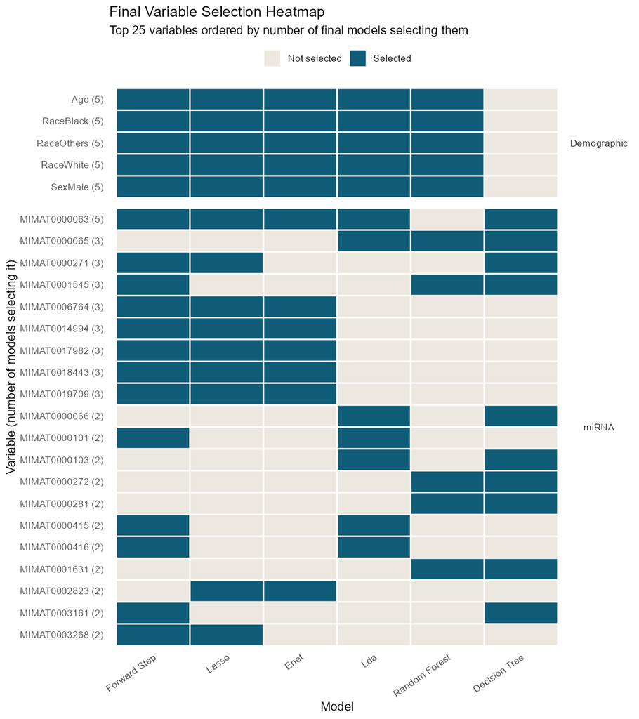

### Random Forest Out-of-Bag Error by Tree Count

For the best random-forest fit at mtry = 20, the final tree count was set to 143 using the minimum 10-tree moving-average OOB classification error after a 25-tree burn-in. The selected forest had raw OOB classification error 0.481 and smoothed OOB classification error 0.482.

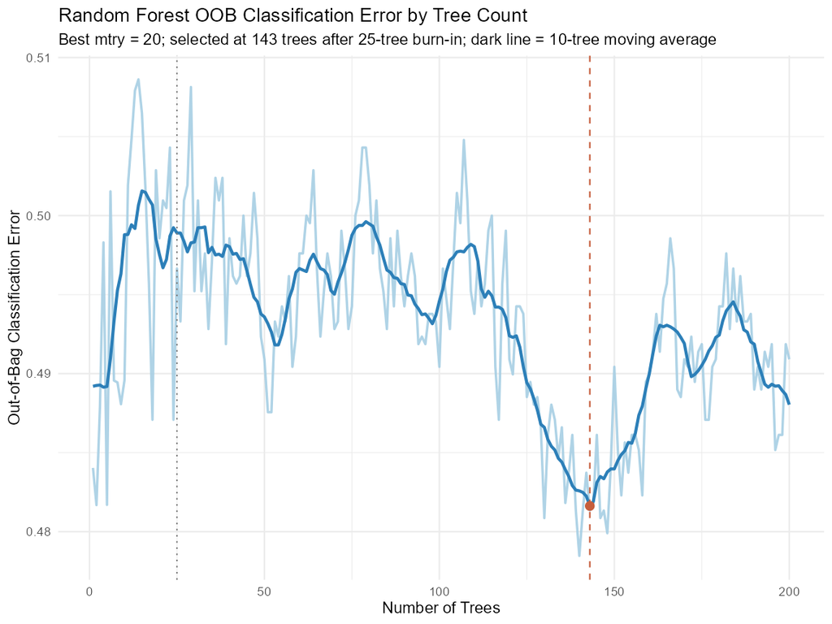

### Random Forest Feature Importance

Rank the final random-forest miRNA candidates by holdout-model feature importance and retain the top M miRNA as the final RF miRNA list.

The final random-forest miRNA list keeps the top 25 miRNA ranked by MeanDecreaseAccuracy from the refit forest using mtry = 20 and ntree = 143.

Random-forest miRNA feature-importance ranking on the final holdout model

| importance_rank | variable | importance_value | MeanDecreaseAccuracy | MeanDecreaseGini | selected_for_final |
| --- | --- | --- | --- | --- | --- |
| 1 | MIMAT0001631 | 0.001 | 0.001 | 3.943 | Yes |
| 2 | MIMAT0000427 | 0.001 | 0.001 | 2.250 | Yes |
| 3 | MIMAT0015020 | 0.001 | 0.001 | 1.877 | Yes |
| 4 | MIMAT0000273 | 0.001 | 0.001 | 2.428 | Yes |
| 5 | MIMAT0001545 | 0.001 | 0.001 | 1.619 | Yes |
| 6 | MIMAT0003220 | 0.001 | 0.001 | 2.226 | Yes |
| 7 | MIMAT0019053 | 0.001 | 0.001 | 2.432 | Yes |
| 8 | MIMAT0000692 | 0.001 | 0.001 | 1.953 | Yes |
| 9 | MIMAT0018925 | 0.000 | 0.000 | 3.281 | Yes |
| 10 | MIMAT0000440 | 0.000 | 0.000 | 3.057 | Yes |
| 11 | MIMAT0000065 | 0.000 | 0.000 | 2.370 | Yes |
| 12 | MIMAT0004985 | 0.000 | 0.000 | 2.577 | Yes |
| 13 | MIMAT0002844 | 0.000 | 0.000 | 1.943 | Yes |
| 14 | MIMAT0002846 | 0.000 | 0.000 | 2.020 | Yes |
| 15 | MIMAT0005923 | 0.000 | 0.000 | 2.891 | Yes |
| 16 | MIMAT0002848 | 0.000 | 0.000 | 1.727 | Yes |
| 17 | MIMAT0018947 | 0.000 | 0.000 | 2.218 | Yes |
| 18 | MIMAT0000092 | 0.000 | 0.000 | 2.326 | Yes |
| 19 | MIMAT0000272 | 0.000 | 0.000 | 2.222 | Yes |
| 20 | MIMAT0017992 | 0.000 | 0.000 | 3.088 | Yes |
| 21 | MIMAT0003266 | 0.000 | 0.000 | 3.064 | Yes |
| 22 | MIMAT0000280 | 0.000 | 0.000 | 3.968 | Yes |
| 23 | MIMAT0000082 | 0.000 | 0.000 | 1.925 | Yes |
| 24 | MIMAT0003332 | 0.000 | 0.000 | 2.604 | Yes |
| 25 | MIMAT0000281 | 0.000 | 0.000 | 1.211 | Yes |

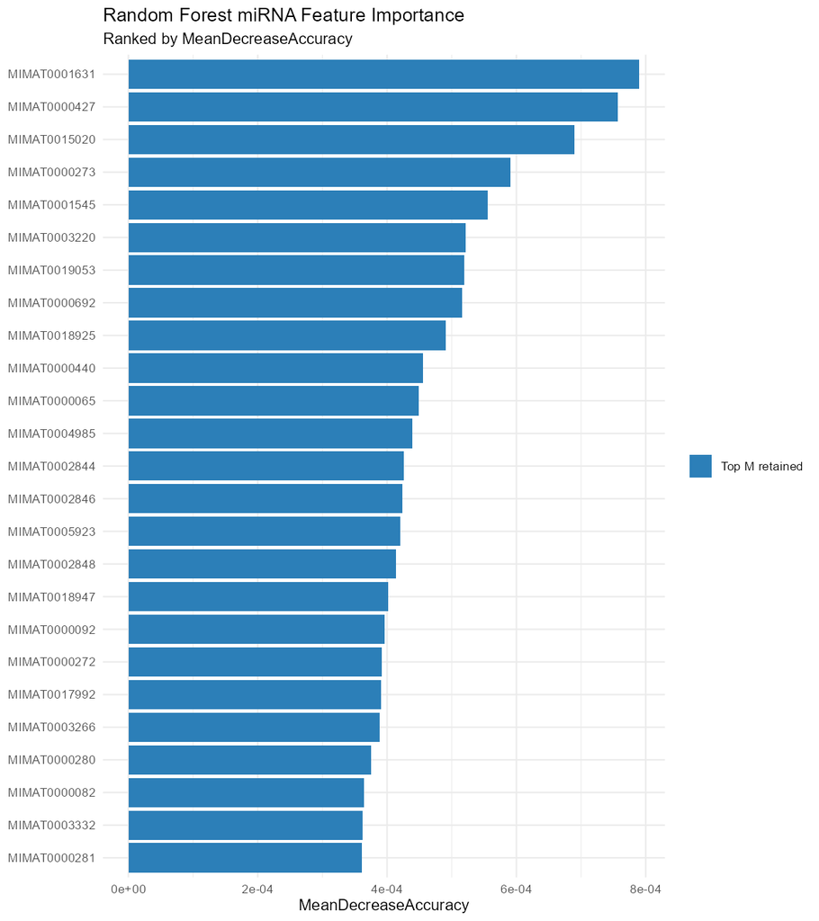

### Decision Tree Cross-Validated Classification Error

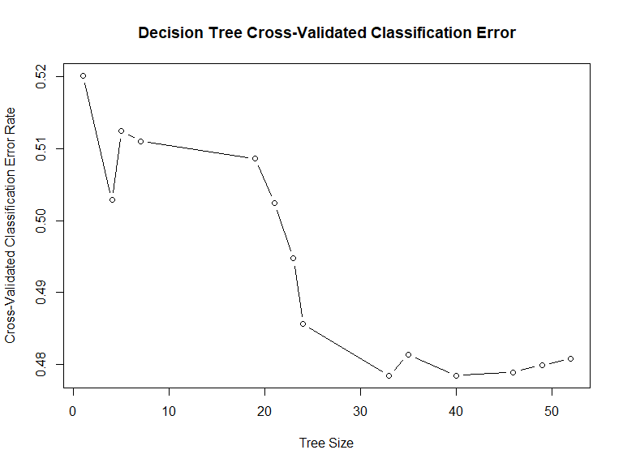

### Lasso and Elastic Net Optimal Alpha

```
## The optimal alpha for the Lasso model is 0.350000.
```

### Decision Tree Feature Importance

For the decision tree, we define selected miRNA as miRNA that appear in one or more primary splits of the final fitted tree, and we separately report the tree’s variable-importance ranking.

For the decision tree, miRNA were considered selected only if they appeared in one or more primary splits of the final tree. The ranking below summarizes each miRNA’s total loss reduction across the fitted tree and distinguishes miRNA used in primary splits from miRNA with nonzero importance only.

Decision-tree miRNA feature-importance ranking on the final holdout model

| importance_rank | variable | importance_value | primary_split_count | selected_for_final |
| --- | --- | --- | --- | --- |
| 1 | MIMAT0000075 | 18.018 | 1 | Yes |
| 2 | MIMAT0003161 | 11.655 | 1 | Yes |
| 3 | MIMAT0000074 | 11.346 | 1 | Yes |
| 4 | MIMAT0000271 | 11.170 | 1 | Yes |
| 5 | MIMAT0001545 | 10.881 | 1 | Yes |
| 6 | MIMAT0005825 | 10.388 | 1 | Yes |
| 7 | MIMAT0000274 | 10.187 | 1 | Yes |
| 8 | MIMAT0003227 | 10.148 | 0 | No |
| 9 | MIMAT0000415 | 8.965 | 0 | No |
| 10 | MIMAT0002890 | 8.814 | 1 | Yes |
| 11 | MIMAT0000066 | 8.799 | 1 | Yes |
| 12 | MIMAT0000751 | 8.773 | 1 | Yes |
| 13 | MIMAT0002854 | 8.616 | 2 | Yes |
| 14 | MIMAT0000270 | 8.359 | 0 | No |
| 15 | MIMAT0018972 | 8.144 | 1 | Yes |
| 16 | MIMAT0005914 | 8.116 | 1 | Yes |
| 17 | MIMAT0000281 | 8.093 | 1 | Yes |
| 18 | MIMAT0019898 | 7.922 | 1 | Yes |
| 19 | MIMAT0002852 | 7.906 | 1 | Yes |
| 20 | MIMAT0000065 | 7.722 | 1 | Yes |
| 21 | MIMAT0000254 | 7.669 | 0 | No |
| 22 | MIMAT0003214 | 7.621 | 0 | No |
| 23 | MIMAT0000687 | 7.584 | 1 | Yes |
| 24 | MIMAT0001631 | 7.447 | 1 | Yes |
| 25 | MIMAT0002883 | 7.397 | 1 | Yes |

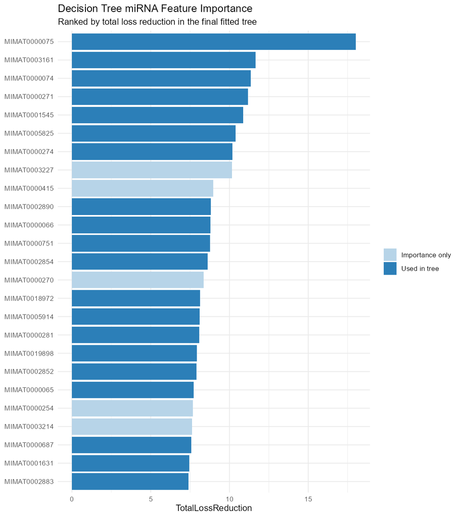

## Calibration Curves and Additional Metrics

Reliability diagrams (calibration curves) and Brier scores for each model on the holdout set

Brier scores by model

| model | brier_score |
| --- | --- |
| lda | 0.2496 |
| enet | 0.2509 |
| lasso | 0.2511 |
| random_forest | 0.2526 |
| forward_step | 0.2699 |
| decision_tree | 0.3319 |

### Forward Step

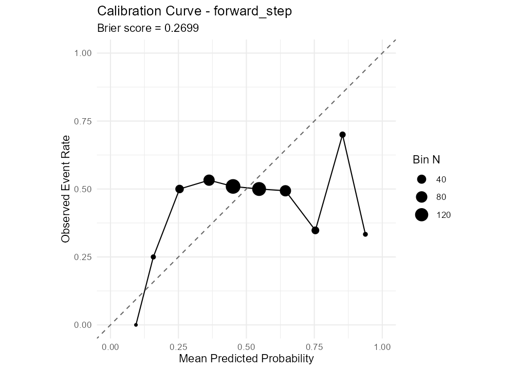

### Lasso

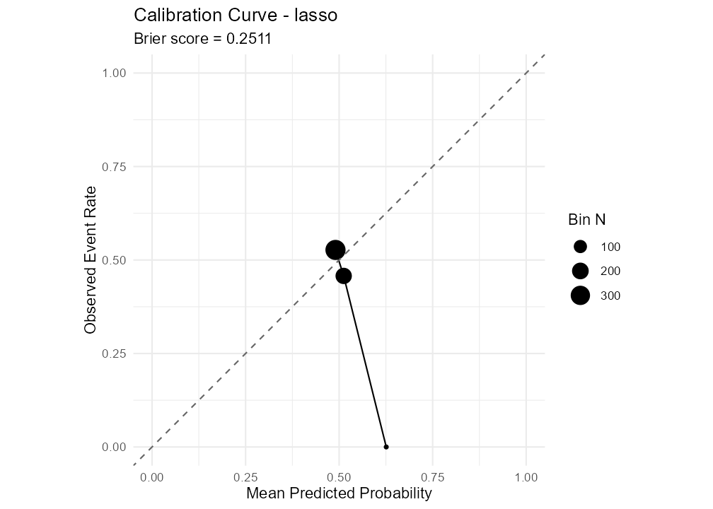

### Enet

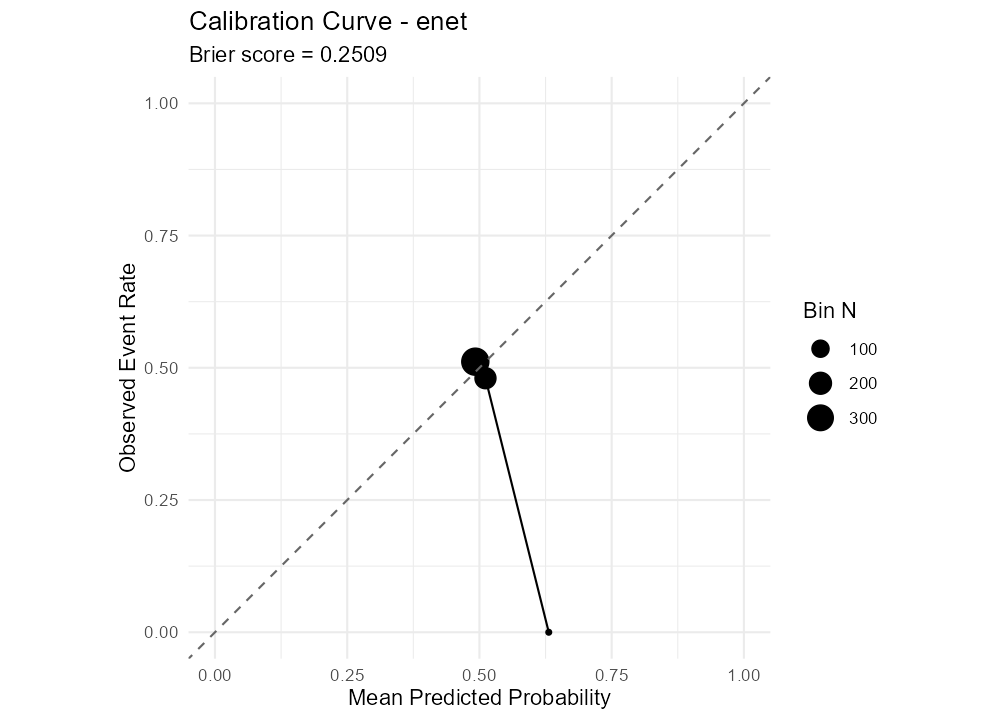

### Lda

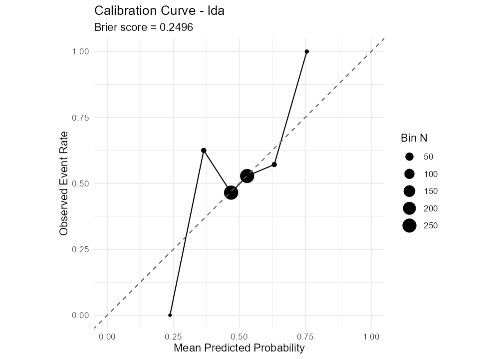

### Random Forest

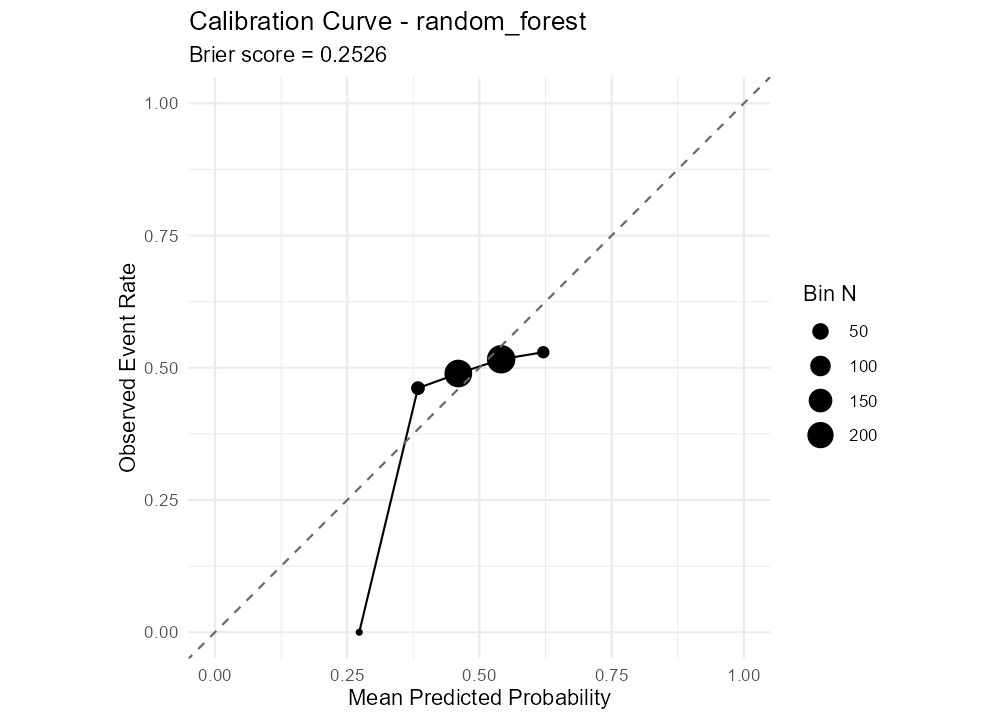

### Decision Tree

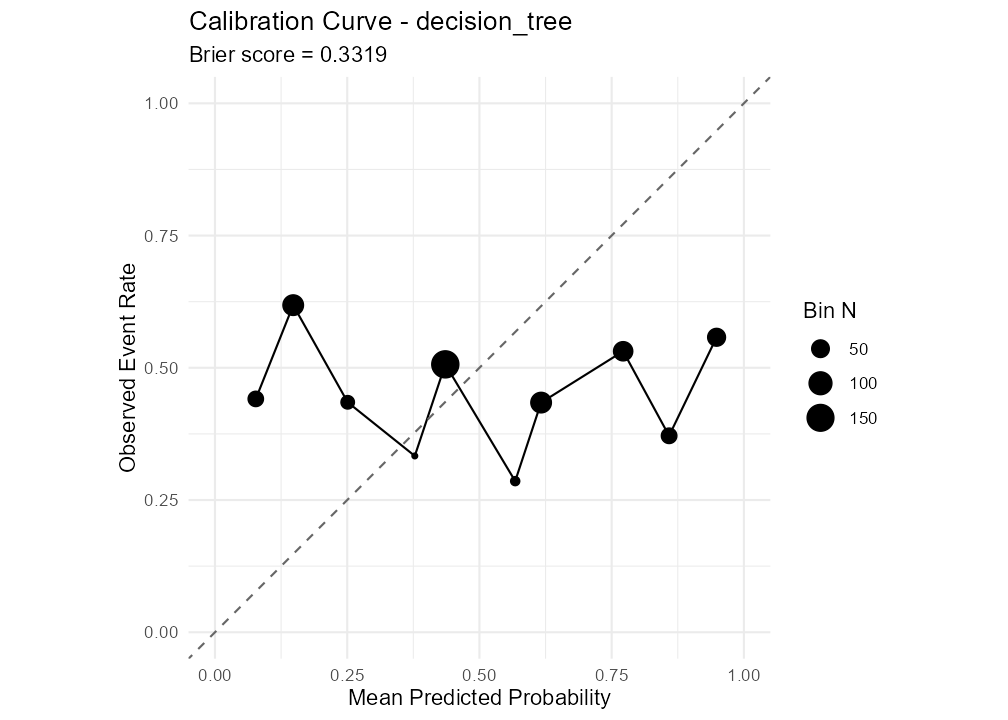

# Interpretation and Visualization

ROC curve comparison of all models on the test set.

Holdout ROC performance summary

| model | test_accuracy | test_auc |
| --- | --- | --- |
| lda | 0.532 | 0.534 |
| lasso | 0.466 | 0.534 |
| enet | 0.485 | 0.529 |
| decision_tree | 0.477 | 0.517 |
| forward_step | 0.490 | 0.508 |
| random_forest | 0.517 | 0.505 |

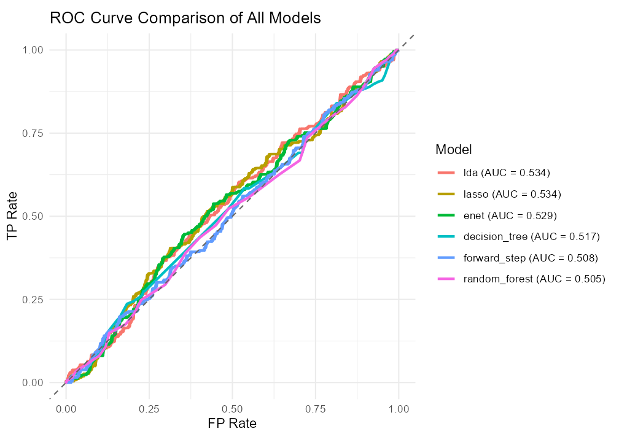

## Confusion Matrices for Final Models

Confusion Matrices for Final Models

| Prediction | Reference | Freq | model |
| --- | --- | --- | --- |
| Controls | Controls | 134 | forward_step |
| PDAC case | Controls | 128 | forward_step |
| Controls | PDAC case | 139 | forward_step |
| PDAC case | PDAC case | 123 | forward_step |
| Controls | Controls | 158 | lasso |
| PDAC case | Controls | 104 | lasso |
| Controls | PDAC case | 176 | lasso |
| PDAC case | PDAC case | 86 | lasso |
| Controls | Controls | 169 | enet |
| PDAC case | Controls | 93 | enet |
| Controls | PDAC case | 177 | enet |
| PDAC case | PDAC case | 85 | enet |
| Controls | Controls | 141 | lda |
| PDAC case | Controls | 121 | lda |
| Controls | PDAC case | 124 | lda |
| PDAC case | PDAC case | 138 | lda |
| Controls | Controls | 134 | random_forest |
| PDAC case | Controls | 128 | random_forest |
| Controls | PDAC case | 125 | random_forest |
| PDAC case | PDAC case | 137 | random_forest |
| Controls | Controls | 139 | decision_tree |
| PDAC case | Controls | 123 | decision_tree |
| Controls | PDAC case | 151 | decision_tree |
| PDAC case | PDAC case | 111 | decision_tree |

## Classification Metrics for Final Models

Precision, Recall, Sensitivity, Specificity, Accuracy, and F1 Score for Final Models

| model | precision | recall | sensitivity | specificity | accuracy | f1_score |
| --- | --- | --- | --- | --- | --- | --- |
| forward_step | 0.490 | 0.469 | 0.469 | 0.511 | 0.490 | 0.480 |
| lasso | 0.453 | 0.328 | 0.328 | 0.603 | 0.466 | 0.381 |
| enet | 0.478 | 0.324 | 0.324 | 0.645 | 0.485 | 0.386 |
| lda | 0.533 | 0.527 | 0.527 | 0.538 | 0.532 | 0.530 |
| random_forest | 0.517 | 0.523 | 0.523 | 0.511 | 0.517 | 0.520 |
| decision_tree | 0.474 | 0.424 | 0.424 | 0.531 | 0.477 | 0.448 |

# Selected miRNA Features and Interpretation

## Final selected miRNA across non-tree models

Counts of non-tree models selecting each miRNA

| miRNA | n_models_selected |
| --- | --- |
| MIMAT0000063 | 4 |
| MIMAT0006764 | 3 |
| MIMAT0014994 | 3 |
| MIMAT0017982 | 3 |
| MIMAT0018443 | 3 |
| MIMAT0019709 | 3 |
| MIMAT0000101 | 2 |
| MIMAT0000271 | 2 |
| MIMAT0000415 | 2 |
| MIMAT0000416 | 2 |
| MIMAT0002823 | 2 |
| MIMAT0003268 | 2 |
| MIMAT0005874 | 2 |
| MIMAT0000062 | 1 |
| MIMAT0000064 | 1 |
| MIMAT0000065 | 1 |
| MIMAT0000066 | 1 |
| MIMAT0000067 | 1 |
| MIMAT0000072 | 1 |
| MIMAT0000087 | 1 |
| MIMAT0000098 | 1 |
| MIMAT0000099 | 1 |
| MIMAT0000102 | 1 |
| MIMAT0000103 | 1 |
| MIMAT0000104 | 1 |
| MIMAT0000253 | 1 |
| MIMAT0000254 | 1 |
| MIMAT0000414 | 1 |
| MIMAT0000450 | 1 |
| MIMAT0000456 | 1 |
| MIMAT0000680 | 1 |
| MIMAT0001545 | 1 |
| MIMAT0002825 | 1 |
| MIMAT0002855 | 1 |
| MIMAT0003161 | 1 |
| MIMAT0003309 | 1 |
| MIMAT0003313 | 1 |
| MIMAT0005454 | 1 |
| MIMAT0005823 | 1 |
| MIMAT0005914 | 1 |
| MIMAT0005953 | 1 |
| MIMAT0015058 | 1 |
| MIMAT0018119 | 1 |
| MIMAT0022839 | 1 |
| MIMAT0031892 | 1 |

Top-rank selection count: 4 of 4 non-tree models

Top-ranked consensus miRNAs from the non-tree models

| miRNA | Annotation | n_models_selected | limma_log_fc | limma_t | limma_p_value | limma_adj_p_value |
| --- | --- | --- | --- | --- | --- | --- |
| MIMAT0000063 | hsa-let-7b-5p | 4 | -0.1539616 | -3.481557 | 0.0005088 | 0.1012441 |

Downstream multiMiR analysis uses all 1 miRNAs in this non-tree consensus set.

## Final selected variables across non-tree models

Counts of non-tree models selecting each variable

| variable | variable_type | n_models_selected |
| --- | --- | --- |
| Age | Demographic | 4 |
| RaceBlack | Demographic | 4 |
| RaceOthers | Demographic | 4 |
| RaceWhite | Demographic | 4 |
| SexMale | Demographic | 4 |
| MIMAT0000063 | miRNA | 4 |
| MIMAT0006764 | miRNA | 3 |
| MIMAT0014994 | miRNA | 3 |
| MIMAT0017982 | miRNA | 3 |
| MIMAT0018443 | miRNA | 3 |
| MIMAT0019709 | miRNA | 3 |
| MIMAT0000101 | miRNA | 2 |
| MIMAT0000271 | miRNA | 2 |
| MIMAT0000415 | miRNA | 2 |
| MIMAT0000416 | miRNA | 2 |
| MIMAT0002823 | miRNA | 2 |
| MIMAT0003268 | miRNA | 2 |
| MIMAT0005874 | miRNA | 2 |
| MIMAT0000062 | miRNA | 1 |
| MIMAT0000064 | miRNA | 1 |
| MIMAT0000065 | miRNA | 1 |
| MIMAT0000066 | miRNA | 1 |
| MIMAT0000067 | miRNA | 1 |
| MIMAT0000072 | miRNA | 1 |
| MIMAT0000087 | miRNA | 1 |
| MIMAT0000098 | miRNA | 1 |
| MIMAT0000099 | miRNA | 1 |
| MIMAT0000102 | miRNA | 1 |
| MIMAT0000103 | miRNA | 1 |
| MIMAT0000104 | miRNA | 1 |
| MIMAT0000253 | miRNA | 1 |
| MIMAT0000254 | miRNA | 1 |
| MIMAT0000414 | miRNA | 1 |
| MIMAT0000450 | miRNA | 1 |
| MIMAT0000456 | miRNA | 1 |
| MIMAT0000680 | miRNA | 1 |
| MIMAT0001545 | miRNA | 1 |
| MIMAT0002825 | miRNA | 1 |
| MIMAT0002855 | miRNA | 1 |
| MIMAT0003161 | miRNA | 1 |
| MIMAT0003309 | miRNA | 1 |
| MIMAT0003313 | miRNA | 1 |
| MIMAT0005454 | miRNA | 1 |
| MIMAT0005823 | miRNA | 1 |
| MIMAT0005914 | miRNA | 1 |
| MIMAT0005953 | miRNA | 1 |
| MIMAT0015058 | miRNA | 1 |
| MIMAT0018119 | miRNA | 1 |
| MIMAT0022839 | miRNA | 1 |
| MIMAT0031892 | miRNA | 1 |

Top-rank selection count: 4 of 4 non-tree models

Top-ranked consensus variables from the non-tree models

| variable | variable_type | Annotation | n_models_selected | limma_log_fc | limma_t | limma_p_value | limma_adj_p_value |
| --- | --- | --- | --- | --- | --- | --- | --- |
| MIMAT0000063 | miRNA | hsa-let-7b-5p | 4 | -0.1539616 | -3.481557 | 0.0005088 | 0.1012441 |
| Age | Demographic | Demographic covariate | 4 | NA | NA | NA | NA |
| RaceBlack | Demographic | Demographic covariate | 4 | NA | NA | NA | NA |
| RaceOthers | Demographic | Demographic covariate | 4 | NA | NA | NA | NA |
| RaceWhite | Demographic | Demographic covariate | 4 | NA | NA | NA | NA |
| SexMale | Demographic | Demographic covariate | 4 | NA | NA | NA | NA |

Multiple variables tied for the highest non-tree model-selection count, so miRNA variables in the table below are ordered by the smallest blocked-limma p-value, with ties broken by the absolute moderated t-statistic and then variable identifier. Demographic covariates do not have blocked-limma statistics and are listed after miRNA variables. The first row is the top-ranked consensus variable used for downstream annotation.

## Comparison of Top-Ranked miRNA by Decision Tree and Random Forest

Limited to top 20 miRNAs for visualization.

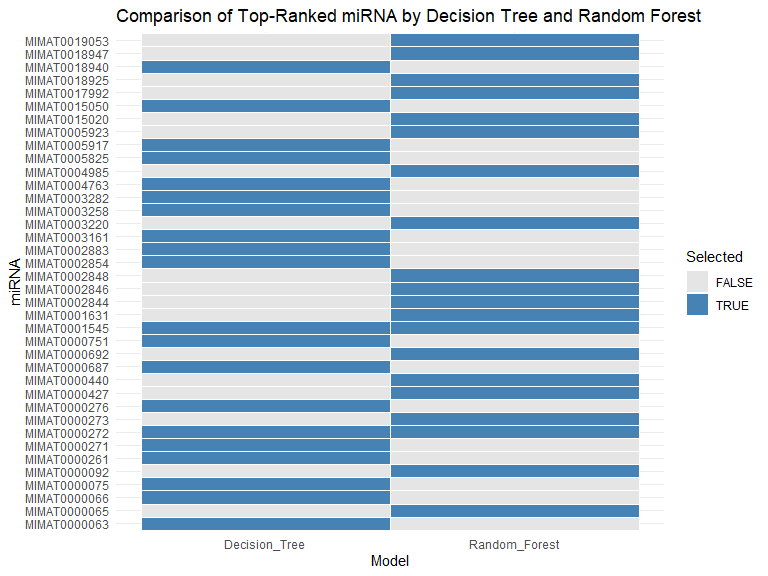

```r
decision_tree_top_miRNA <- final_model_outputs[["decision_tree"]]$selected_miRNA
random_forest_top_miRNA <- final_model_outputs[["random_forest"]]$selected_miRNA
decision_tree_top_miRNA <- head(decision_tree_top_miRNA, 20)
random_forest_top_miRNA <- head(random_forest_top_miRNA, 20)

comparison_df <- tibble(
  miRNA = union(decision_tree_top_miRNA, random_forest_top_miRNA),
  Decision_Tree = miRNA %in% decision_tree_top_miRNA,
  Random_Forest = miRNA %in% random_forest_top_miRNA
)

comparison_df_long <- comparison_df %>%
  pivot_longer(cols = c("Decision_Tree", "Random_Forest"), names_to = "Model", values_to = "Selected")

ggplot(comparison_df_long, aes(x = Model, y = miRNA, fill = Selected)) +
  geom_tile(color = "white") +
  scale_fill_manual(values = c("TRUE" = "steelblue", "FALSE" = "grey90")) +
  theme_minimal() +
  labs(title = "Comparison of Top-Ranked miRNA by Decision Tree and Random Forest", x = "Model", y = "miRNA")
```

## Merging of Selected and Ranked Features by All Models

```
##  [1] "MIMAT0000063" "MIMAT0000687" "MIMAT0000261" "MIMAT0015050" "MIMAT0003161"
##  [6] "MIMAT0001545" "MIMAT0001631" "MIMAT0000427" "MIMAT0015020" "MIMAT0000273"
```

Report runtime: 00:37:32 (started 2026-04-23 18:01:14; finished 2026-04-23 18:38:46).